# Atividade prática n. 2

## Questão 8:

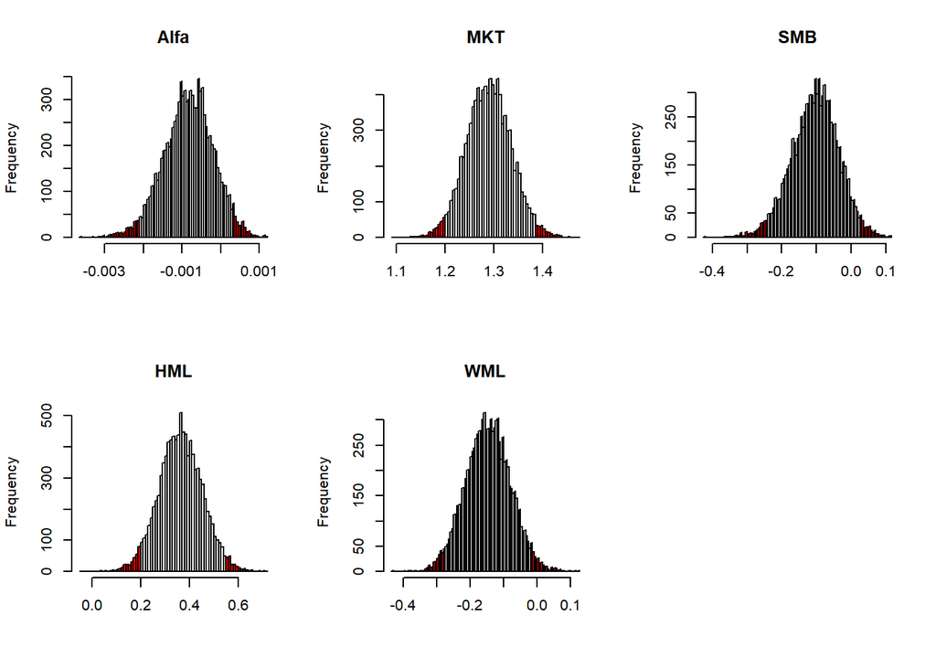

```r
results <- matrix(,
                  nrow = 10000,
                  ncol = 5)
name_coeficientes <- c("Alfa", "MKT", "SMB", "HML", "WML")
colnames(results) <- name_coeficientes
for (i in 1: 10000){
  index_amostras <- sample(1:547,300,T)
  amostra <- data[index_amostras,]
  mod <- lm(PORT-RF ~ MKT + SMB + HML + WML ,data=amostra)
  results[i,] <- mod$coefficients
}

par(mfrow=c(2,3))
for (name in name_coeficientes){
  Hist<-hist(results[,name], plot=F, breaks = 100)
  plot(Hist, main=name, xlab="",col=ifelse(Hist$breaks <= quantile(results[,name],0.025) , "red", ifelse (Hist$breaks >=quantile(results[,name],0.975), "red", "white")))
}
```

Segundo o teste de robuste, pegando amostras aleatorias e rodando uma regressão em cima dela, ocorreu que o Alfa, o MKT, o SMB, o HML e o WML se estabilizaram em uma normal de media semelhante ao previsto pela amostra global, como apresentando na celula a seguir:

```r
output <- matrix(,nrow=4,ncol=5)
colnames(output) <- name_coeficientes
estatisticas <- c("Minimo","Media","Maximo","Desvio Padrao")
rownames(output) <- estatisticas
for (coeficiente in name_coeficientes){
  output["Minimo",coeficiente] <- min(results[,coeficiente])
  output["Media",coeficiente] <- median(results[,coeficiente])
  output["Maximo",coeficiente] <- max(results[,coeficiente])
  output["Desvio Padrao",coeficiente] <- sd(results[,coeficiente])
}
mod_completo <- lm(PORT-RF ~ MKT + SMB + HML + WML ,data=data)
```

```
## [1] "-------------------- Teste de Robustes --------------------"
```

```
##                        Alfa        MKT        SMB         HML         WML
## Minimo        -0.0036480687 1.09101492 -0.4200557 -0.04531841 -0.43314783
## Media         -0.0008180033 1.28928546 -0.1012699  0.36423658 -0.14727700
## Maximo         0.0011763099 1.47020456  0.1112069  0.71329267  0.12001228
## Desvio Padrao  0.0006346320 0.04607052  0.0673775  0.08911999  0.06686329
```

```
## [1] "-------------------- Modelo Completo --------------------"
```

```
##   (Intercept)           MKT           SMB           HML           WML
## -0.0008312782  1.2922833910 -0.1004157278  0.3621468964 -0.1432652786
```

Como visivel pela estatistica, a media de todos os coeficientes do teste de robustes se aproximaram do real valor de testes do modelo completo, mostrando que o modelo está coerente.

## Creditos:

*Hlavac, Marek (2018). stargazer: Well-Formatted Regression and Summary Statistics Tables.*